# Stock Market - Case Study

The R Bootcamp @ Erfurt [www.therbootcamp.com](https://therbootcamp.github.io) [@therbootcamp](https://twitter.com/therbootcamp)

## Overview

In this case study, you will evaluate the development of three major stock indices, the **Dow Jones**, the **DAX**, and the **Nikkei**, over the last few decades and their relationships to the exchange rates between the respective currencies, the **US dollar**, the **Euro**, and the **Yen**. You will address several questions: How large was the impact of the recent financial crisis on the stock indices? How correlated is the development between the three stock indices? What is the relationship between stock indices and exchange rates?

To address these questions, you perform the following steps. First, you will import several raw data files. Importing these data files will require that you adjust some of the import parameters to account for minor idiosyncracies of the individual data files. Next, you will merge data files into a single data frame and create new variables that reflect changes in index prices and exchange rates. Using the combined data, you then analyze correlations of index prices and exchange rates. Finally, you will create plots illustrating the results of these analyses.

Below you will find a series of small tasks that will guide you through these steps. For the most part these tasks require you to make use of what you have learned in the sessions **Intro to R**, **Data Wrangling**, and **Statistics**. However, they will also go beyond. In these cases, you will often have to do some figuring out on your own using, for instance, the help files of individual functions. In several cases, you will also be provided with important code snippets and explanations to help you complete the tasks.

Remember: Struggle, ask for help, struggle! Good luck!

Variables of data sets “^DJI.csv”, “^GDAXI.csv”, “^N225.csv”

| Variable | Description |
| --- | --- |
| Date | Current day |
| Open | Day’s price when the stock exchange opened |
| High | Day’s highest price |
| Low | Day’s lowest price |
| Close | Day’s closing price |
| Adj Close | Adjusted closing price that has been amended to include any distributions and corporate actions that occurred at any time prior to the next day’s open |

Variables of data sets “euro-dollar.txt”, “yen-dollar.txt”

| Variable | Description |
| --- | --- |
| Date (currently unnamed) | Current day |
| Rate (currently unnamed) | Day’s exchange rate in terms of 1 US Dollar. E.g., a value of .75 means that the respective currenty is worth a fraction of .75 of 1 US Dollar |

## Intro to R

1. Open a new R script and save it as a new file called `finance_case_study.R`. At the top of the script, using comments, write your name and the date. Then, load the `tidyverse`package. Here’s how the top of your script should look:

```r
## NAME
## DATE
## Sales Data - Case Study

library(tidyverse)
```

2. Import the stock index data sets, “^DJI.csv”, “^GDAXI.csv”, and “^N225.csv”, from the data folder, using the `read_csv()`-function. In so doing, explicitly set the `na`-argument to account for the fact that “^GDAXI.csv” “^N225.csv” contain a specific character string to represent missings in the data. To do this, you must first identify the string used to represent `NA`s. To do this open one of the files in a standard text viewer, e.g., *textedit*, and brows through the data file. When you have identfied the character string, set the `na`-argument to that character string and import the data.

```r
# Load index data from local data folder
dow <- read_csv(file = '^DJI.csv')
dax <- read_csv(file = '^GDAXI.csv', na = 'null')
nik <- read_csv(file = '^N225.csv', na = 'null')
```

3. Import the exchange rate data sets, “euro-dollar.txt” and “yen-dollar.txt”, from the data folder, using the `read_delim()`-function. To account for the specific delimiter used in the data sets, set the `delim`-argument to `\t` (the *tabulator* symbol). After having read in the data, inspect the inferred data types and variables names. Something’s wrong, right? We want the columns names to be something like `Date` and `Rate` (and not values taken from the first row of data). To achieve this, set the `col_names`-argument to a vector that specifies the said variable names. We also want the `Date`-variable to be of type `date`. You can achieve this using the `parse_date()`-function with the `format`-argument set to `'%d %b %Y'`, which tells R the format the dates comes in. For simplicity, simply overwrite the existing `Date`-variable the vector of `Date`-values created by `parse_date()`.

```r
# Load exchange rate data from local data folder
eur_usd <- read_delim(file = 'euro-dollar.txt', delim = '\t', col_names = c('Date', 'Rate'))
yen_usd <- read_delim(file = 'yen-dollar.txt', delim = '\t', col_names = c('Date', 'Rate'))

# change Date to date type
eur_usd$Date <- parse_date(eur_usd$Date, format = '%d %b %Y')
yen_usd$Date <- parse_date(yen_usd$Date, format = '%d %b %Y')
```

4. Great, now that you’ve imported the different datasets, spend some time and get an impression of the datasets using `print()`, `typeof()` and `str()`. What type are the data objects, what variables do they contain?

```r
# Inspect data
typeof(dow) ; str(dow)
```

```
## [1] "list"
```

```
## Classes 'tbl_df', 'tbl' and 'data.frame':    8364 obs. of  7 variables:
##  $ Date     : Date, format: "1985-01-29" "1985-01-30" ...
##  $ Open     : num  1278 1297 1283 1277 1272 ...
##  $ High     : num  1295 1305 1293 1286 1295 ...
##  $ Low      : num  1267 1279 1273 1270 1269 ...
##  $ Close    : num  1293 1288 1287 1278 1290 ...
##  $ Adj Close: num  1293 1288 1287 1278 1290 ...
##  $ Volume   : int  13560000 16820000 14070000 10980000 11630000 13800000 14610000 11440000 8000000 12600000 ...
##  - attr(*, "spec")=List of 2
##   ..$ cols   :List of 7
##   .. ..$ Date     :List of 1
##   .. .. ..$ format: chr ""
##   .. .. ..- attr(*, "class")= chr  "collector_date" "collector"
##   .. ..$ Open     : list()
##   .. .. ..- attr(*, "class")= chr  "collector_double" "collector"
##   .. ..$ High     : list()
##   .. .. ..- attr(*, "class")= chr  "collector_double" "collector"
##   .. ..$ Low      : list()
##   .. .. ..- attr(*, "class")= chr  "collector_double" "collector"
##   .. ..$ Close    : list()
##   .. .. ..- attr(*, "class")= chr  "collector_double" "collector"
##   .. ..$ Adj Close: list()
##   .. .. ..- attr(*, "class")= chr  "collector_double" "collector"
##   .. ..$ Volume   : list()
##   .. .. ..- attr(*, "class")= chr  "collector_integer" "collector"
##   ..$ default: list()
##   .. ..- attr(*, "class")= chr  "collector_guess" "collector"
##   ..- attr(*, "class")= chr "col_spec"
```

```r
typeof(dax) ; str(dax)
```

```
## [1] "list"
```

```
## Classes 'tbl_df', 'tbl' and 'data.frame':    7811 obs. of  7 variables:
##  $ Date     : Date, format: "1987-12-30" "1987-12-31" ...
##  $ Open     : num  1005 NA NA 956 996 ...
##  $ High     : num  1005 NA NA 956 996 ...
##  $ Low      : num  1005 NA NA 956 996 ...
##  $ Close    : num  1005 NA NA 956 996 ...
##  $ Adj Close: num  1005 NA NA 956 996 ...
##  $ Volume   : int  0 NA NA 0 0 0 0 0 0 0 ...
##  - attr(*, "spec")=List of 2
##   ..$ cols   :List of 7
##   .. ..$ Date     :List of 1
##   .. .. ..$ format: chr ""
##   .. .. ..- attr(*, "class")= chr  "collector_date" "collector"
##   .. ..$ Open     : list()
##   .. .. ..- attr(*, "class")= chr  "collector_double" "collector"
##   .. ..$ High     : list()
##   .. .. ..- attr(*, "class")= chr  "collector_double" "collector"
##   .. ..$ Low      : list()
##   .. .. ..- attr(*, "class")= chr  "collector_double" "collector"
##   .. ..$ Close    : list()
##   .. .. ..- attr(*, "class")= chr  "collector_double" "collector"
##   .. ..$ Adj Close: list()
##   .. .. ..- attr(*, "class")= chr  "collector_double" "collector"
##   .. ..$ Volume   : list()
##   .. .. ..- attr(*, "class")= chr  "collector_integer" "collector"
##   ..$ default: list()
##   .. ..- attr(*, "class")= chr  "collector_guess" "collector"
##   ..- attr(*, "class")= chr "col_spec"
```

```r
typeof(nik) ; str(nik)
```

```
## [1] "list"
```

```
## Classes 'tbl_df', 'tbl' and 'data.frame':    13722 obs. of  7 variables:
##  $ Date     : Date, format: "1965-01-05" "1965-01-06" ...
##  $ Open     : num  1258 1264 1274 1286 NA ...
##  $ High     : num  1258 1264 1274 1286 NA ...
##  $ Low      : num  1258 1264 1274 1286 NA ...
##  $ Close    : num  1258 1264 1274 1286 NA ...
##  $ Adj Close: num  1258 1264 1274 1286 NA ...
##  $ Volume   : int  0 0 0 0 NA 0 0 0 NA 0 ...
##  - attr(*, "spec")=List of 2
##   ..$ cols   :List of 7
##   .. ..$ Date     :List of 1
##   .. .. ..$ format: chr ""
##   .. .. ..- attr(*, "class")= chr  "collector_date" "collector"
##   .. ..$ Open     : list()
##   .. .. ..- attr(*, "class")= chr  "collector_double" "collector"
##   .. ..$ High     : list()
##   .. .. ..- attr(*, "class")= chr  "collector_double" "collector"
##   .. ..$ Low      : list()
##   .. .. ..- attr(*, "class")= chr  "collector_double" "collector"
##   .. ..$ Close    : list()
##   .. .. ..- attr(*, "class")= chr  "collector_double" "collector"
##   .. ..$ Adj Close: list()
##   .. .. ..- attr(*, "class")= chr  "collector_double" "collector"
##   .. ..$ Volume   : list()
##   .. .. ..- attr(*, "class")= chr  "collector_integer" "collector"
##   ..$ default: list()
##   .. ..- attr(*, "class")= chr  "collector_guess" "collector"
##   ..- attr(*, "class")= chr "col_spec"
```

```r
typeof(eur_usd) ; str(eur_usd)
```

```
## [1] "list"
```

```
## Classes 'tbl_df', 'tbl' and 'data.frame':    6546 obs. of  2 variables:
##  $ Date: Date, format: "1999-01-04" "1999-01-05" ...
##  $ Rate: num  1.19 1.18 1.16 1.17 1.16 ...
##  - attr(*, "spec")=List of 2
##   ..$ cols   :List of 2
##   .. ..$ Date: list()
##   .. .. ..- attr(*, "class")= chr  "collector_character" "collector"
##   .. ..$ Rate: list()
##   .. .. ..- attr(*, "class")= chr  "collector_double" "collector"
##   ..$ default: list()
##   .. ..- attr(*, "class")= chr  "collector_guess" "collector"
##   ..- attr(*, "class")= chr "col_spec"
```

```r
typeof(yen_usd) ; str(yen_usd)
```

```
## [1] "list"
```

```
## Classes 'tbl_df', 'tbl' and 'data.frame':    8765 obs. of  2 variables:
##  $ Date: Date, format: "1990-01-02" "1990-01-03" ...
##  $ Rate: num  0.00684 0.00686 0.00698 0.00695 0.00694 ...
##  - attr(*, "spec")=List of 2
##   ..$ cols   :List of 2
##   .. ..$ Date: list()
##   .. .. ..- attr(*, "class")= chr  "collector_character" "collector"
##   .. ..$ Rate: list()
##   .. .. ..- attr(*, "class")= chr  "collector_double" "collector"
##   ..$ default: list()
##   .. ..- attr(*, "class")= chr  "collector_guess" "collector"
##   ..- attr(*, "class")= chr "col_spec"
```

## Data Wrangling

5. To analyze the data is is often useful to have all relevant variables in a single data frame. Create now a single data frame containing one variable containing the dates, each stock index’ (unadjusted) closing prices, and the two exchange rates. Do this by *piping* (i.e., using `%>%`) together several `inner_join()`-functions. That is, first join datasets one and two, then join the combined data set of one and two with dataset three, and so on. Set the `by`-argument to `Date`. When done, rename the variables appropriately using the `rename()`-function (which can also be *piped*, i.e., added, to the `join`-commands).

Note that when joining two data sets, you can control the naming of overlapping variable names using the `suffix`-argument. Also note that `inner_join()` takes care of the fact that different dates are available in each of the data sets by only retaining dates for which all data sets provide data on.

```r
# create single data frame
data = dow %>% select('Date','Close') %>%
  inner_join(dax %>% select('Date','Close'), by = 'Date', suffix = c('_dow','_dax')) %>%
  inner_join(nik %>% select('Date','Close'), by = 'Date') %>%
  inner_join(eur_usd, by = 'Date') %>%
  inner_join(yen_usd, by = 'Date', suffix = c('_eur','_yen')) %>%
  rename('Close_nik' = 'Close')
```

6. Create new variables containing the change in index price and exchange rate for each variable using the `mutate()`-function. Vectors that reflect value changes can conveniently computed using the `diff()`-function. Note that since `diff()` will return `n - 1` change values, you have to add an `NA` at the first position of the change variable à la `c(NA, diff(my_variable))`.

```r
# create variables representing day-to-day changes
data = data %>% mutate(
  Close_dow_change = c(NA, diff(Close_dow)),
  Close_dax_change = c(NA, diff(Close_dax)),
  Close_nik_change = c(NA, diff(Close_nik)),
  Rate_eur_change = c(NA, diff(Rate_eur)),
  Rate_yen_change = c(NA, diff(Rate_yen))
)
```

7. Create a variable containing merely the year of the date variable using `mutate()` and the `year()`-function from the `lubridate`-package (should have been installed with the `tidyverse`, if not install using `install.packages()`). Don’t forget to load the package before using it.

```r
# load lubridate
library(lubridate)

# create year variable
data = data %>% mutate(year = year(Date))
```

8. Finally, create a long version of data frame that represents variables as different rows rather than columns. Do this using the `gather()`-function from the `tidyr`-package (also part of the `tidyverse`) via the command below. You may have to adjust the object/variable names. Check out the example in the `?gather`-help file. When done, inspect the object and compare it (visually) to the original, wide version.

```r
# create long version of data frame
long_data = data %>% gather(variable, value, -Date, -year)
```

## Statistics (& Plotting)

8. Now let us visually inspect some of the relationships. Plot the price development of the three stock indices using the code below (based on the long data object). The code uses a modern and very powerful plotting package called `ggplot2`, which you will be introduced to later in the course. For the code to work, you may have to adjust the object and variable names to match the ones in your data frame. Inspecting the plot, do you see a significant drop anywhere?

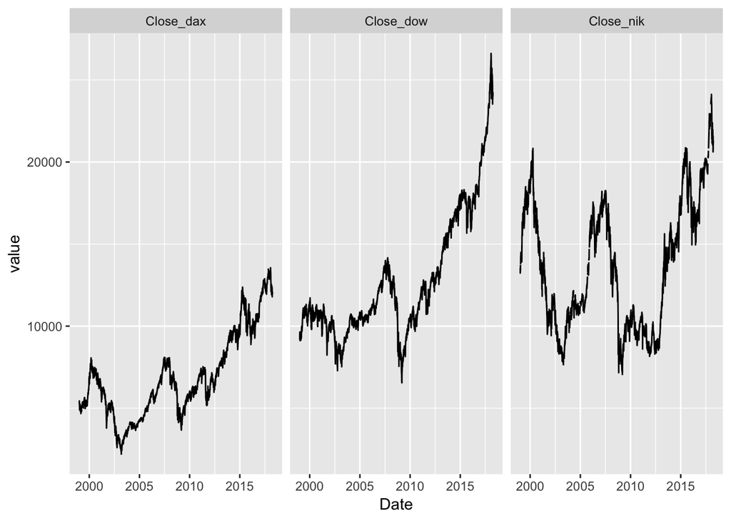

```r
# create long version of data frame
temp_data <- long_data %>% filter(variable %in% c("Close_dow","Close_dax","Close_nik"))
ggplot(data = temp_data, mapping = aes(x = Date, y = value)) +
  geom_line() +
  facet_grid(~variable)
```

9. What do the numbers say? Calculate the overall stock index price change per year. Use `group_by()`, `summarize()`, and `sum()` on the stock index change variables. Remember the `NA`’s in two of the stock index price variables. You have to deal with them. When was the biggest drop in stock index prices?

```r
# calculate aggregate change per year
aggregate_change <- data %>%
  group_by(year) %>%
  summarize(
    mean_dow_change = sum(Close_dow_change),
    mean_dax_change = sum(Close_dax_change, na.rm = T),
    mean_nik_change = sum(Close_nik_change, na.rm = T)
)
aggregate_change
```

```
## # A tibble: 20 x 4
##     year mean_dow_change mean_dax_change mean_nik_change
##    <dbl>           <dbl>           <dbl>           <dbl>
##  1  1999            NA             1529.          5903.
##  2  2000          -709.            -455.         -5561.
##  3  2001          -766.           -1254.         -4436.
##  4  2002         -1680.           -2112.         -2235.
##  5  2003          2112.             718.           327.
##  6  2004           329.             180.          1335.
##  7  2005           -65.5           1108.          3219.
##  8  2006          1746.            1189.          1504.
##  9  2007           903.            1470.         -1918.
## 10  2008         -4697.           -3257.         -6448.
## 11  2009          1880.            1147.          1513.
## 12  2010          1021.             957.          -318.
## 13  2011           648.           -1016.         -1774.
## 14  2012           721.            1714.          1940.
## 15  2013          3566.            1940.          5896.
## 16  2014          1479.             253.          1159.
## 17  2015          -379.             937.          1583.
## 18  2016          2159.             738.            80.7
## 19  2017          4957.            1266.          3439.
## 20  2018          -455.            -960.         -2395.
```

10. Now that you know the time at which the biggest drop occured, you may wonder which stock indices was most affected? Compare the overall losses in index prices on the first trading day of the respective year. To do this, identify the first date available for that year and then `filter()` to select the value for the first trading day. Then divide the overall change in in that year’s stock price that the first day’s closing price. Which stock index suffered the greatest relative loss?

```r
aggregate_change %>%
  filter(year == 2008) %>%
  select(-1) / data %>%
  filter(Date == "2008-01-04") %>%
  select(Close_dow, Close_dax, Close_nik)
```

```
##   mean_dow_change mean_dax_change mean_nik_change
## 1      -0.3669855      -0.4171147      -0.4389109
```

11. The results, so far, seem tosuggest large co-dependencies between financial markets, in the sense that a change in one market can bring about changes in other markets. Evaluate this aspect of financial markets more directly by correlating the stock index change variables among each other using `cor()`.

Note that `cor()` produces the full correlation matrix when provided with a data frame. Also, don’t forget about the `NA`s - there is an argument for `cor()` to deal with them. Take a look at `?cor`. How closely are the stock indices related and which ones are most closely related?

```r
data %>%
  select(Close_dow_change, Close_dax_change, Close_nik_change) %>%
  cor(., use = 'complete.obs')
```

```
##                  Close_dow_change Close_dax_change Close_nik_change
## Close_dow_change        1.0000000        0.5702655        0.1685651
## Close_dax_change        0.5702655        1.0000000        0.3178292
## Close_nik_change        0.1685651        0.3178292        1.0000000
```

12. Evaluate the stability of the relationships between financial markets by analyzing the correlations for each year. To do this use the `group_by()` and `summarize()`-functions.

Note that, in this case, you will have to specify each pairwise correlation separately.

```r
data %>%
  group_by(year) %>%
  summarize(
    cor_dow_dax = cor(Close_dow_change, Close_dax_change, use = 'complete.obs'),
    cor_dow_nik = cor(Close_dow_change, Close_nik_change, use = 'complete.obs'),
    cor_dax_nik = cor(Close_dax_change, Close_nik_change, use = 'complete.obs')
)
```

```
## # A tibble: 20 x 4
##     year cor_dow_dax cor_dow_nik cor_dax_nik
##    <dbl>       <dbl>       <dbl>       <dbl>
##  1  1999       0.453      0.0730       0.192
##  2  2000       0.308     -0.0519       0.195
##  3  2001       0.667      0.255        0.287
##  4  2002       0.654      0.196        0.236
##  5  2003       0.695      0.127        0.249
##  6  2004       0.468      0.166        0.344
##  7  2005       0.390      0.0625       0.327
##  8  2006       0.594      0.100        0.266
##  9  2007       0.537      0.0874       0.394
## 10  2008       0.613      0.212        0.527
## 11  2009       0.732      0.175        0.260
## 12  2010       0.695      0.255        0.329
## 13  2011       0.796      0.185        0.351
## 14  2012       0.725      0.212        0.325
## 15  2013       0.566      0.161        0.256
## 16  2014       0.567      0.149        0.176
## 17  2015       0.538      0.254        0.295
## 18  2016       0.605      0.214        0.387
## 19  2017       0.554      0.367        0.395
## 20  2018       0.378      0.108        0.481
```

13. Another important index of the financial markets is the exchange rate of its currency to that of other markets. Commonly, it is assumed that a strong economcy translates in both a strong stock index and a strong currency relative to other currencies. Towards evaluating this claim, that stock index prices and exchange rates move the same way, begin by evaluating whether exchange rate changes correlate with each other the same way that stock indices do.

```r
data %>%
  select(Rate_eur_change, Rate_yen_change) %>%
  cor(., use = 'complete.obs')
```

```
##                 Rate_eur_change Rate_yen_change
## Rate_eur_change       1.0000000       0.3913418
## Rate_yen_change       0.3913418       1.0000000
```

14. Now evaluate directly whether exchange rates co-vary with differences between stock indices prices. For instance, does a large difference between Dow Jones and DAX translate into a strong Dollar relative to the EURO? Based on the above intuition this should be the case. However, economic theorizing has also lead to postulating the alternative hypothesis. Foreign investors who benefit from a rise in stock index price, so the logic, may be motivated to sell their holdings and exhange them for their own currency to mantain a balanced portfolio. This would, in effect, lead to a depreciation of the currency at the same time as the stock index is outperforming and thus to a negative relationship between the two variables. What do you think? Ask the data.

```r
data %>%
  summarize(
    cor_dow_dax = cor(Close_dow - Close_dax, Rate_eur, use = 'complete.obs'),
    cor_dow_nik = cor(Close_dow - Close_nik, Rate_yen, use = 'complete.obs')
  )
```

```
## # A tibble: 1 x 2
##   cor_dow_dax cor_dow_nik
##         <dbl>       <dbl>
## 1      0.0869       0.569
```

15. Finally, evaluate the stability of the above relationship for each year separately? Can you make out a stable pattern? No? I guess it depends.

```r
data %>%
  group_by(year) %>%
  summarize(
    cor_dow_dax = cor(Close_dow - Close_dax, Rate_eur, use = 'complete.obs'),
    cor_dow_nik = cor(Close_dow - Close_nik, Rate_yen, use = 'complete.obs')
  )
```

```
## # A tibble: 20 x 3
##     year cor_dow_dax cor_dow_nik
##    <dbl>       <dbl>       <dbl>
##  1  1999      -0.639     -0.501
##  2  2000      -0.222     -0.479
##  3  2001      -0.393     -0.221
##  4  2002       0.162     -0.287
##  5  2003       0.772     -0.320
##  6  2004       0.253      0.427
##  7  2005       0.831      0.862
##  8  2006       0.776      0.0745
##  9  2007      -0.136      0.824
## 10  2008       0.825      0.788
## 11  2009       0.837      0.740
## 12  2010       0.714      0.932
## 13  2011      -0.334      0.459
## 14  2012      -0.248      0.727
## 15  2013      -0.235      0.898
## 16  2014      -0.856      0.781
## 17  2015       0.601      0.819
## 18  2016      -0.108      0.831
## 19  2017       0.784      0.629
## 20  2018       0.470      0.792
```

### References

https://www.weforum.org/agenda/2015/07/whats-the-relationship-between-stock-returns-and-exchange-rates/ http://www.faz.net/aktuell/finanzen/aktien/eine-geschichte-des-dax-die-wichtigsten-ereignisse-12970011.html